# Determining MLB underpaid and overpaid players

```r
library(tidyr)
library(ggplot2)
library(dplyr)
library(plotly)
library(scales)
```

Import the relevant data

```r
path <- "../Data/baseballdatabank-2019.2/core/"
salaries <- read.csv(paste0(path, "Salaries.csv"))
players <- read.csv(paste0(path, "People.csv"))
batting <- read.csv(paste0(path, "Batting.csv"))
pitchers <- read.csv(paste0(path, "Pitching.csv"))
head(players)
```

|  | playerID | birthYear | birthMonth | birthDay | birthCountry | birthState | birthCity | deathYear | deathMonth | deathDay | deathCountry | deathState | deathCity | nameFirst | nameLast | nameGiven | weight | height | bats | throws | debut | finalGame | retroID | bbrefID |
| --- | --- | --- | --- | --- | --- | --- | --- | --- | --- | --- | --- | --- | --- | --- | --- | --- | --- | --- | --- | --- | --- | --- | --- | --- |
| 1 | aardsda01 | 1981 | 12 | 27 | USA | CO | Denver | NA | NA | NA |  |  |  | David | Aardsma | David Allan | 215 | 75 | R | R | 2004-04-06 | 2015-08-23 | aardd001 | aardsda01 |
| 2 | aaronha01 | 1934 | 2 | 5 | USA | AL | Mobile | NA | NA | NA |  |  |  | Hank | Aaron | Henry Louis | 180 | 72 | R | R | 1954-04-13 | 1976-10-03 | aaroh101 | aaronha01 |
| 3 | aaronto01 | 1939 | 8 | 5 | USA | AL | Mobile | 1984 | 8 | 16 | USA | GA | Atlanta | Tommie | Aaron | Tommie Lee | 190 | 75 | R | R | 1962-04-10 | 1971-09-26 | aarot101 | aaronto01 |
| 4 | aasedo01 | 1954 | 9 | 8 | USA | CA | Orange | NA | NA | NA |  |  |  | Don | Aase | Donald William | 190 | 75 | R | R | 1977-07-26 | 1990-10-03 | aased001 | aasedo01 |
| 5 | abadan01 | 1972 | 8 | 25 | USA | FL | Palm Beach | NA | NA | NA |  |  |  | Andy | Abad | Fausto Andres | 184 | 73 | L | L | 2001-09-10 | 2006-04-13 | abada001 | abadan01 |
| 6 | abadfe01 | 1985 | 12 | 17 | D.R. | La Romana | La Romana | NA | NA | NA |  |  |  | Fernando | Abad | Fernando Antonio | 220 | 73 | L | L | 2010-07-28 | 2017-10-01 | abadf001 | abadfe01 |

Plot the Salary Data overall, by national league, and by American League

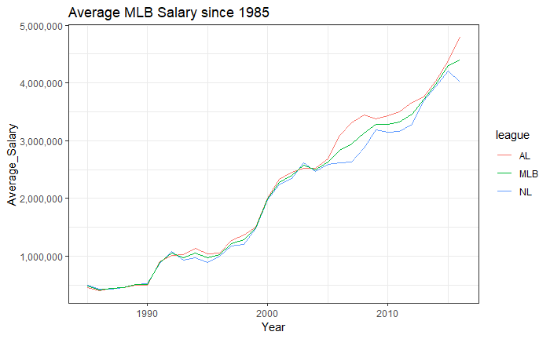

```r
salaries <- salaries %>% select(year = yearID, team = teamID, league = lgID, playerID, salary)
avg_salaries_by_league <- salaries %>% group_by(year, league) %>% summarise(avg_salary_league_year = mean(salary)) %>% ungroup()
avg_salaries_by_year <- salaries %>% group_by(year) %>% summarise(avg_salary_league = mean(salary)) %>% ungroup()
ggplot() + geom_line(data = avg_salaries_by_league, aes(x = year, y = avg_salary_league_year, color = league)) +
  geom_line(data = avg_salaries_by_year, aes(x = year, y = avg_salary_league, color = "MLB")) + xlab("Year") + ylab("Average_Salary") + ggtitle("Average MLB Salary since 1985") +  scale_y_continuous(labels = comma) + theme_bw()
```

Boxplot of salaries for each year since 2012 (seems the salaries have been relatively skewed)

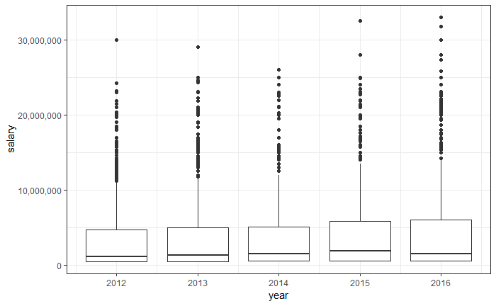

```r
recent_salaries <- salaries %>% filter(year >= 2012)
recent_salaries %>% ggplot(aes(group = year, x = year, y = salary)) + geom_boxplot() + theme_bw() + scale_y_continuous(labels = comma)
```

Make year_id on salaries table

```r
salaries <- salaries %>% mutate(year_id = paste(playerID, year, sep="_")) %>% select(year_id, salary)
```

Begin to feature engineer the batting table

```r
#in case the player had multiple stints
batting <- batting %>% filter(yearID >= 1985, AB > 100) %>% group_by(playerID, year = yearID) %>% summarise( G = sum(G), AB = sum(AB),R = sum(R), H = sum(H), X2B = sum(X2B), X3B = sum(X3B), HR = sum(HR), RBI = sum(RBI), SB = sum(SB), CS = sum(CS), BB = sum(BB), SO = sum(SO), IBB = sum(IBB), HBP = sum(HBP), SH = sum(SH), SF = sum(SF), GIDP = sum(GIDP)) %>% mutate(BA = H/AB, OBP = (H + BB + HBP)/(AB + BB + HBP + SF), SLG = (H + X2B + 2*X3B + 3*HR)/AB, OPS = OBP + SLG, TA = (BB + HBP + SB + SLG*AB - CS)/(AB - H + CS + GIDP), GPA = (1.8 * OBP + SLG)/4) %>% ungroup()
head(batting)
```

| playerID | year | G | AB | R | H | X2B | X3B | HR | RBI | SB | CS | BB | SO | IBB | HBP | SH | SF | GIDP | BA | OBP | SLG | OPS | TA | GPA |
| --- | --- | --- | --- | --- | --- | --- | --- | --- | --- | --- | --- | --- | --- | --- | --- | --- | --- | --- | --- | --- | --- | --- | --- | --- |
| abbotje01 | 1998 | 89 | 244 | 33 | 68 | 14 | 1 | 12 | 41 | 3 | 3 | 9 | 28 | 1 | 0 | 2 | 5 | 2 | 0.2786885 | 0.2984496 | 0.4918033 | 0.7902529 | 0.7127072 | 0.2572531 |
| abbotje01 | 2000 | 80 | 215 | 31 | 59 | 15 | 1 | 3 | 29 | 2 | 1 | 21 | 38 | 1 | 2 | 2 | 1 | 2 | 0.2744186 | 0.3430962 | 0.3953488 | 0.7384451 | 0.6855346 | 0.2532305 |
| abbotku01 | 1994 | 101 | 345 | 41 | 86 | 17 | 3 | 9 | 33 | 3 | 0 | 16 | 98 | 1 | 5 | 3 | 2 | 5 | 0.2492754 | 0.2907609 | 0.3942029 | 0.6849638 | 0.6060606 | 0.2293931 |
| abbotku01 | 1995 | 120 | 420 | 60 | 107 | 18 | 7 | 17 | 60 | 4 | 3 | 36 | 110 | 4 | 5 | 2 | 5 | 6 | 0.2547619 | 0.3175966 | 0.4523810 | 0.7699775 | 0.7204969 | 0.2560137 |
| abbotku01 | 1996 | 109 | 320 | 37 | 81 | 18 | 7 | 8 | 33 | 3 | 3 | 22 | 99 | 1 | 3 | 4 | 0 | 7 | 0.2531250 | 0.3072464 | 0.4281250 | 0.7353714 | 0.6506024 | 0.2452921 |
| abbotku01 | 1997 | 94 | 252 | 35 | 69 | 18 | 2 | 6 | 30 | 3 | 1 | 14 | 68 | 3 | 1 | 6 | 0 | 5 | 0.2738095 | 0.3146067 | 0.4325397 | 0.7471464 | 0.6666667 | 0.2497080 |

feature engineer the player info table

```r
players <- players %>% separate(debut, "debut_year", sep="-") %>%

  select(playerID, birthYear, nameFirst,  nameLast, debut_year)
```

```
Expected 1 pieces. Additional pieces discarded in 19420 rows [1, 2, 3, 4, 5, 6, 7, 8, 9, 10, 11, 12, 13, 14, 15, 16, 17, 18, 19, 20, ...].
```

Join player_info with batting data on playerID, and then join that with salaries

```r
batting <- inner_join(batting, players, by = "playerID") %>%
  mutate(year_id = paste(playerID, year, sep="_"))
```

```
Column `playerID` joining factors with different levels, coercing to character vector
```

```r
batting <- inner_join(batting, salaries, by = "year_id") %>% mutate(yearsPlaying = year - as.numeric(debut_year))
head(batting)
```

| playerID | year | G | AB | R | H | X2B | X3B | HR | RBI | SB | CS | BB | SO | IBB | HBP | SH | SF | GIDP | BA | OBP | SLG | OPS | TA | GPA | birthYear | nameFirst | nameLast | debut_year | year_id | … |
| --- | --- | --- | --- | --- | --- | --- | --- | --- | --- | --- | --- | --- | --- | --- | --- | --- | --- | --- | --- | --- | --- | --- | --- | --- | --- | --- | --- | --- | --- | --- |
| abbotje01 | 1998 | 89 | 244 | 33 | 68 | 14 | 1 | 12 | 41 | 3 | 3 | 9 | 28 | 1 | 0 | 2 | 5 | 2 | 0.2786885 | 0.2984496 | 0.4918033 | 0.7902529 | 0.7127072 | 0.2572531 | 1972 | Jeff | Abbott | 1997 | abbotje01_1998 | … |
| abbotje01 | 2000 | 80 | 215 | 31 | 59 | 15 | 1 | 3 | 29 | 2 | 1 | 21 | 38 | 1 | 2 | 2 | 1 | 2 | 0.2744186 | 0.3430962 | 0.3953488 | 0.7384451 | 0.6855346 | 0.2532305 | 1972 | Jeff | Abbott | 1997 | abbotje01_2000 | … |
| abbotku01 | 1994 | 101 | 345 | 41 | 86 | 17 | 3 | 9 | 33 | 3 | 0 | 16 | 98 | 1 | 5 | 3 | 2 | 5 | 0.2492754 | 0.2907609 | 0.3942029 | 0.6849638 | 0.6060606 | 0.2293931 | 1969 | Kurt | Abbott | 1993 | abbotku01_1994 | … |
| abbotku01 | 1995 | 120 | 420 | 60 | 107 | 18 | 7 | 17 | 60 | 4 | 3 | 36 | 110 | 4 | 5 | 2 | 5 | 6 | 0.2547619 | 0.3175966 | 0.4523810 | 0.7699775 | 0.7204969 | 0.2560137 | 1969 | Kurt | Abbott | 1993 | abbotku01_1995 | … |
| abbotku01 | 1996 | 109 | 320 | 37 | 81 | 18 | 7 | 8 | 33 | 3 | 3 | 22 | 99 | 1 | 3 | 4 | 0 | 7 | 0.2531250 | 0.3072464 | 0.4281250 | 0.7353714 | 0.6506024 | 0.2452921 | 1969 | Kurt | Abbott | 1993 | abbotku01_1996 | … |
| abbotku01 | 1997 | 94 | 252 | 35 | 69 | 18 | 2 | 6 | 30 | 3 | 1 | 14 | 68 | 3 | 1 | 6 | 0 | 5 | 0.2738095 | 0.3146067 | 0.4325397 | 0.7471464 | 0.6666667 | 0.2497080 | 1969 | Kurt | Abbott | 1993 | abbotku01_1997 | … |

Normalize salary by year

```r
batting <- batting %>% group_by(year) %>% mutate(avg_salary = mean(salary), sd_salary = sd(salary)) %>% ungroup() %>% mutate(zSalary = (salary - avg_salary)/sd(salary))
tail(batting)
```

| playerID | year | G | AB | R | H | X2B | X3B | HR | RBI | SB | CS | BB | SO | IBB | HBP | SH | SF | GIDP | BA | OBP | SLG | OPS | TA | GPA | birthYear | nameFirst | nameLast | debut_year | year_id | … |
| --- | --- | --- | --- | --- | --- | --- | --- | --- | --- | --- | --- | --- | --- | --- | --- | --- | --- | --- | --- | --- | --- | --- | --- | --- | --- | --- | --- | --- | --- | --- |
| zobribe01 | 2016 | 147 | 523 | 94 | 142 | 31 | 3 | 18 | 76 | 6 | 4 | 96 | 82 | 6 | 4 | 4 | 4 | 17 | 0.2715105 | 0.3859649 | 0.4455067 | 0.8314716 | 0.8333333 | 0.2850609 | 1981 | Ben | Zobrist | 2006 | zobribe01_2016 | … |
| zuletju01 | 2001 | 49 | 106 | 11 | 23 | 3 | 0 | 6 | 24 | 0 | 1 | 8 | 32 | 1 | 3 | 0 | 1 | 3 | 0.2169811 | 0.2881356 | 0.4150943 | 0.7032299 | 0.6206897 | 0.2334346 | 1975 | Julio | Zuleta | 2000 | zuletju01_2001 | … |
| zuninmi01 | 2014 | 131 | 438 | 51 | 87 | 20 | 2 | 22 | 60 | 0 | 3 | 17 | 158 | 1 | 17 | 0 | 4 | 12 | 0.1986301 | 0.2542017 | 0.4041096 | 0.6583113 | 0.5683060 | 0.2154182 | 1991 | Mike | Zunino | 2013 | zuninmi01_2014 | … |
| zuninmi01 | 2015 | 112 | 350 | 28 | 61 | 11 | 0 | 11 | 28 | 0 | 1 | 21 | 132 | 0 | 5 | 8 | 2 | 6 | 0.1742857 | 0.2301587 | 0.3000000 | 0.5301587 | 0.4391892 | 0.1785714 | 1991 | Mike | Zunino | 2013 | zuninmi01_2015 | … |
| zupcibo01 | 1992 | 124 | 392 | 46 | 108 | 19 | 1 | 3 | 43 | 2 | 2 | 25 | 60 | 1 | 4 | 7 | 4 | 6 | 0.2755102 | 0.3223529 | 0.3520408 | 0.6743938 | 0.5719178 | 0.2330690 | 1966 | Bob | Zupcic | 1991 | zupcibo01_1992 | … |
| zupcibo01 | 1993 | 141 | 286 | 40 | 69 | 24 | 2 | 2 | 26 | 5 | 2 | 27 | 54 | 2 | 2 | 8 | 3 | 7 | 0.2412587 | 0.3081761 | 0.3601399 | 0.6683160 | 0.5973451 | 0.2287142 | 1966 | Bob | Zupcic | 1991 | zupcibo01_1993 | … |

EDA on batting statistics

```r
boxplot(batting$BA, ylab = "Batting Average", main = "Batting Average since 1985")
boxplot(batting$OBP, ylab = "On Base Percentage",main = "OBP since 1985")
boxplot(batting$SLG, ylab = "Slugging Percentage", main = "SLG since 1985")
boxplot(batting$OPS, ylab = "OPS", main = "OPS since 1985")

summary(batting$BA)
summary(batting$OBP)
summary(batting$SLG)
summary(batting$OPS)
```

Now let’s remove pitchers from the batters and see if this changes any metrics (since they usually bat poorly)

```r
batting_no_pitchers <- anti_join(batting, pitchers, by = "playerID")
```

```
Column `playerID` joining character vector and factor, coercing into character vector
```

EDA on batting statistics

```r
boxplot(batting_no_pitchers$BA, ylab = "Batting Average", main = "Batting Average since 1985")
boxplot(batting_no_pitchers$OBP, ylab = "On Base Percentage",main = "OBP since 1985")
boxplot(batting_no_pitchers$SLG, ylab = "Slugging Percentage", main = "SLG since 1985")
boxplot(batting_no_pitchers$OPS, ylab = "OPS", main = "OPS since 1985")


summary(batting_no_pitchers$BA)
summary(batting_no_pitchers$OBP)
summary(batting_no_pitchers$SLG)
summary(batting_no_pitchers$OPS)
```

Batting Average vs Salary

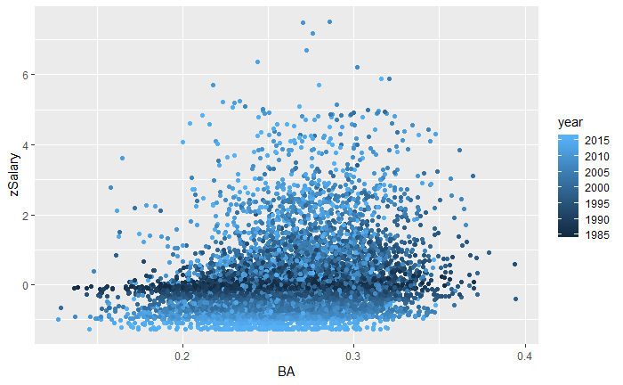

```r
batting_no_pitchers %>% ggplot(aes(x = BA, y = zSalary, color = year)) + geom_point()
```

```r
cor(batting_no_pitchers$zSalary, batting_no_pitchers$BA, use = "pairwise.complete")
```

```
[1] 0.2050528
```

OBP vs Salary

```r
batting_no_pitchers %>% ggplot(aes(x = OBP, y = zSalary, color = year)) + geom_point()
cor(batting_no_pitchers$zSalary, batting_no_pitchers$OBP, use = "pairwise.complete")
```

SLG vs Salary

```r
batting_no_pitchers %>% ggplot(aes(x = SLG, y = zSalary, color = year)) + geom_point()
cor(batting_no_pitchers$zSalary, batting_no_pitchers$SLG, use = "pairwise.complete")
```

OPS vs salary

```r
batting_no_pitchers %>% ggplot(aes(x = OPS, y = zSalary, color = year)) + geom_point()
cor(batting_no_pitchers$zSalary, batting_no_pitchers$OPS, use = "pairwise.complete")
```

YearsPlaying vs Salary

```r
batting_no_pitchers %>% ggplot(aes(x = yearsPlaying, y = zSalary, color = year)) + geom_point()
cor(batting_no_pitchers$zSalary, batting_no_pitchers$yearsPlaying, use = "pairwise.complete")
```

Home runs vs Salary

```r
batting_no_pitchers %>% ggplot(aes(x = HR, y = zSalary, color = year)) + geom_point()
cor(batting_no_pitchers$zSalary, batting_no_pitchers$HR, use = "pairwise.complete")
```

RBIs vs Salary

```r
batting_no_pitchers %>% ggplot(aes(x = RBI, y = zSalary, color = year)) + geom_point()
cor(batting_no_pitchers$zSalary, batting_no_pitchers$RBI, use = "pairwise.complete")
```

TA vs Salary

```r
batting_no_pitchers %>% ggplot(aes(x = TA, y = zSalary, color = year)) + geom_point()
cor(batting_no_pitchers$zSalary, batting_no_pitchers$TA, use = "pairwise.complete")
```

GPA vs Salary

```r
batting_no_pitchers %>% ggplot(aes(x = GPA, y = zSalary, color = year)) + geom_point()
cor(batting_no_pitchers$zSalary, batting_no_pitchers$GPA, use = "pairwise.complete")
```

It seems there are some (loose) correlations between key batting attributes and salaries. Let’s filter the data to recent years and see if the salary has more correlation today with these features than it did with the same features in the past

```r
recent_batting <- batting_no_pitchers %>% filter(year > 2010)
```

Recent batting BA

```r
recent_batting %>% ggplot(aes(x = BA, y = zSalary, color = year)) + geom_point()
cor(recent_batting$zSalary, recent_batting$BA, use = "pairwise.complete")
```

Recent Batting OBP

```r
recent_batting %>% ggplot(aes(x = OBP, y = zSalary, color = year)) + geom_point()
cor(recent_batting$zSalary, recent_batting$OBP, use = "pairwise.complete")
```

Recent Batting SLG

```r
recent_batting %>% ggplot(aes(x = SLG, y = zSalary, color = year)) + geom_point()
cor(recent_batting$zSalary, recent_batting$SLG, use = "pairwise.complete")
```

Recent Batting OPS

```r
recent_batting %>% ggplot(aes(x = OPS, y = zSalary, color = year)) + geom_point()
cor(recent_batting$zSalary, recent_batting$OPS, use = "pairwise.complete")
```

Recent Batting TA

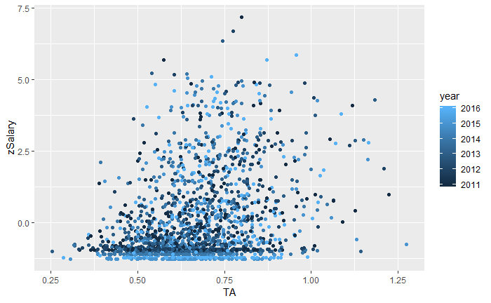

```r
recent_batting %>% ggplot(aes(x = TA, y = zSalary, color = year)) + geom_point()
```

```r
cor(recent_batting$zSalary, recent_batting$TA, use = "pairwise.complete")
```

```
[1] 0.2978157
```

Recent Batting GPA

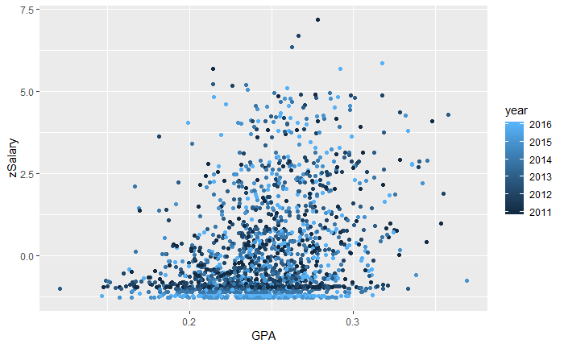

```r
recent_batting %>% ggplot(aes(x = GPA, y = zSalary, color = year)) + geom_point()
```

```r
cor(recent_batting$zSalary, recent_batting$GPA, use = "pairwise.complete")
```

```
[1] 0.3068712
```

Recent Batting Years Playing

```r
recent_batting %>% ggplot(aes(x = yearsPlaying, y = zSalary, color = year)) + geom_point()
cor(recent_batting$zSalary, recent_batting$yearsPlaying, use = "pairwise.complete")
```

Let’s examine free agency salaries and see if their side by side boxplots look any different.

```r
fa_recent_batting <- recent_batting %>% filter(yearsPlaying >= 6)
non_fa_recent_batting <- recent_batting %>% filter(yearsPlaying < 6)
```

Side by side boxplot

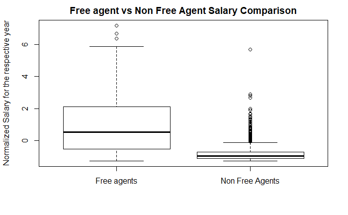

There is a huge difference, but there seem to be a lot of outliers in the non free agents. Let’s examine them more closely

```r
#calculate upper bound for outliers
non_fa_salary_UB = quantile(non_fa_recent_batting$zSalary, .75) + 1.5* IQR(non_fa_recent_batting$zSalary)
fa_salary_UB = quantile(fa_recent_batting$zSalary, .75) + 1.5* IQR(fa_recent_batting$zSalary)
#Get the outliers and normal
non_fa_salary_outliers <- non_fa_recent_batting %>% filter(zSalary >= non_fa_salary_UB)
non_fa_salary_normal <- non_fa_recent_batting %>% filter(zSalary < non_fa_salary_UB)
fa_salary_outliers <- fa_recent_batting %>% filter(zSalary >= fa_salary_UB)
fa_salary_normal <- fa_recent_batting %>% filter(zSalary < fa_salary_UB)
```

It is interesting to compare key performance metric data between outliers and non-outliers for non-FAs

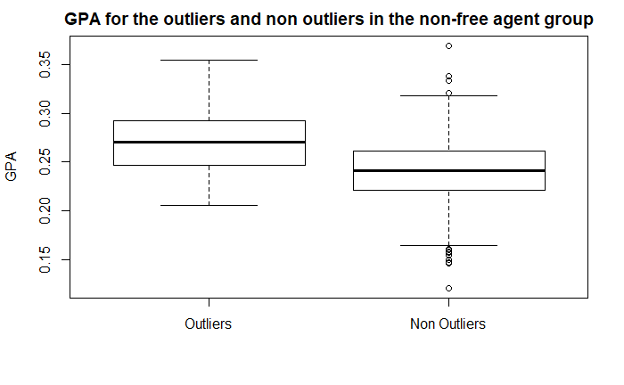

We can see that most people in the non-free agent group have worse key batting metrics overall. Let’s look at the free agent (FA) group

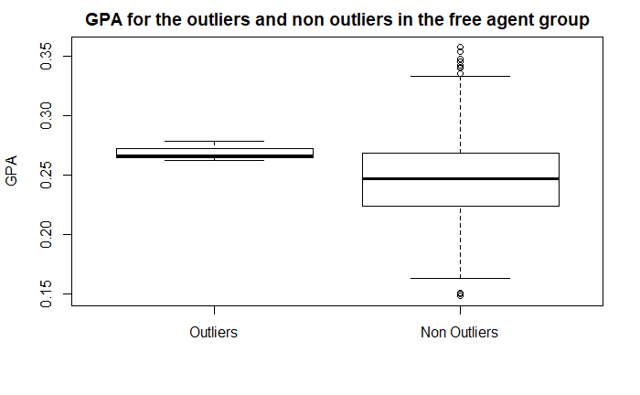

On these performance metrics, the outliers have a higher median metric but the non-outliers have a higher range, which means that these people with better performance stats are likely being underpaid for their work

```r
cor(nonRookies$zSalary, nonRookies$HR)
```

[output not shown]

```
[1] 0.3788035
```